# R Notebook sandbox: Assignment “Datasets” (10 points) Revisited

```r
levels(iris[,5]);
```

```
## [1] "setosa"     "versicolor" "virginica"
```

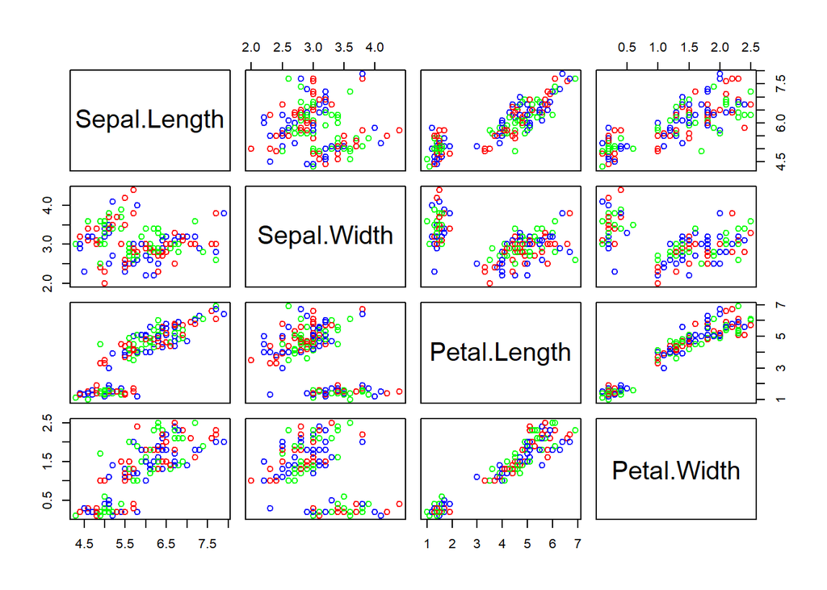

```r
myColors = c("red","green","blue");
plot(iris[,-5],col=myColors);
```

```r
species = as.numeric(iris[,5]);

as.numeric(iris[,5]);  # map to myColors ...
```

```
##   [1] 1 1 1 1 1 1 1 1 1 1 1 1 1 1 1 1 1 1 1 1 1 1 1 1 1 1 1 1 1 1 1 1 1 1 1 1 1
##  [38] 1 1 1 1 1 1 1 1 1 1 1 1 1 2 2 2 2 2 2 2 2 2 2 2 2 2 2 2 2 2 2 2 2 2 2 2 2
##  [75] 2 2 2 2 2 2 2 2 2 2 2 2 2 2 2 2 2 2 2 2 2 2 2 2 2 2 3 3 3 3 3 3 3 3 3 3 3
## [112] 3 3 3 3 3 3 3 3 3 3 3 3 3 3 3 3 3 3 3 3 3 3 3 3 3 3 3 3 3 3 3 3 3 3 3 3 3
## [149] 3 3
```

```r
species = as.numeric(iris[,5]);
myColors[species]
```

```
##   [1] "red"   "red"   "red"   "red"   "red"   "red"   "red"   "red"   "red"
##  [10] "red"   "red"   "red"   "red"   "red"   "red"   "red"   "red"   "red"
##  [19] "red"   "red"   "red"   "red"   "red"   "red"   "red"   "red"   "red"
##  [28] "red"   "red"   "red"   "red"   "red"   "red"   "red"   "red"   "red"
##  [37] "red"   "red"   "red"   "red"   "red"   "red"   "red"   "red"   "red"
##  [46] "red"   "red"   "red"   "red"   "red"   "green" "green" "green" "green"
##  [55] "green" "green" "green" "green" "green" "green" "green" "green" "green"
##  [64] "green" "green" "green" "green" "green" "green" "green" "green" "green"
##  [73] "green" "green" "green" "green" "green" "green" "green" "green" "green"
##  [82] "green" "green" "green" "green" "green" "green" "green" "green" "green"
##  [91] "green" "green" "green" "green" "green" "green" "green" "green" "green"
## [100] "green" "blue"  "blue"  "blue"  "blue"  "blue"  "blue"  "blue"  "blue"
## [109] "blue"  "blue"  "blue"  "blue"  "blue"  "blue"  "blue"  "blue"  "blue"
## [118] "blue"  "blue"  "blue"  "blue"  "blue"  "blue"  "blue"  "blue"  "blue"
## [127] "blue"  "blue"  "blue"  "blue"  "blue"  "blue"  "blue"  "blue"  "blue"
## [136] "blue"  "blue"  "blue"  "blue"  "blue"  "blue"  "blue"  "blue"  "blue"
## [145] "blue"  "blue"  "blue"  "blue"  "blue"  "blue"
```

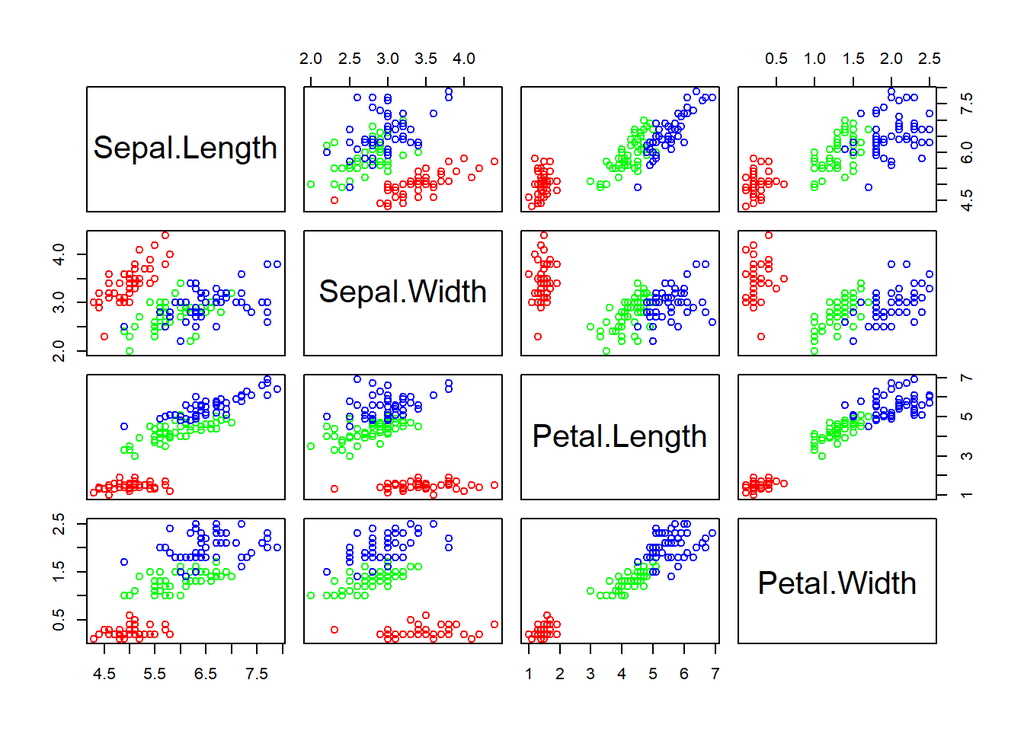

```r
plot(iris[,-5],col=myColors[species]);
```

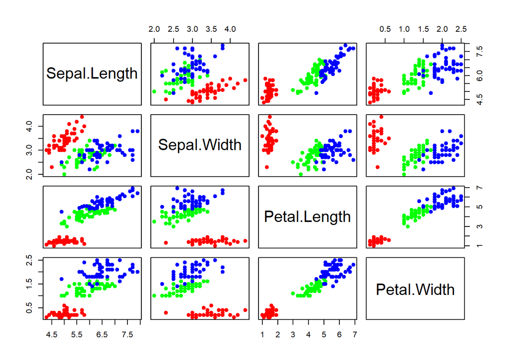

```r
plot(iris[,-5],col=myColors[species], pch=19);
```

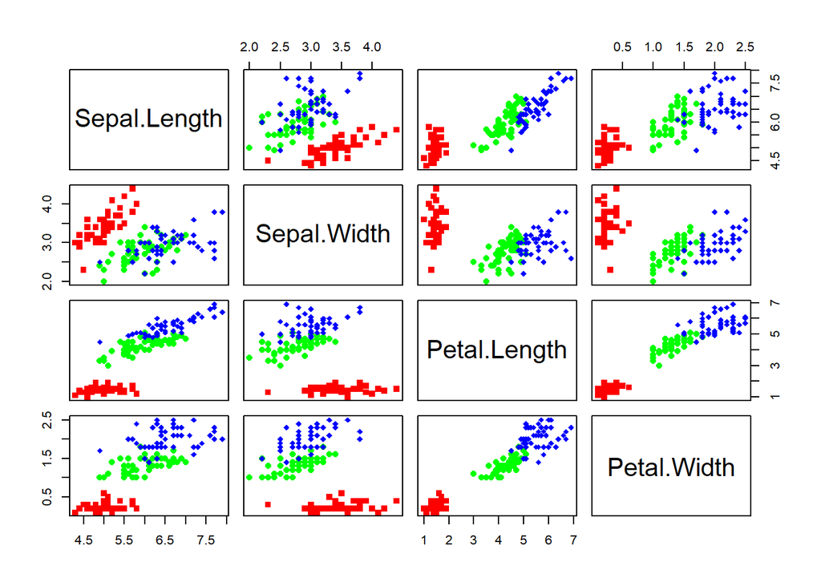

```r
myColors = c("red","green","blue");
mySymbols = c(15, 16, 18);
species = as.numeric(iris[,5]);
plot(iris[,-5],col=myColors[species], pch=mySymbols[species]);
```

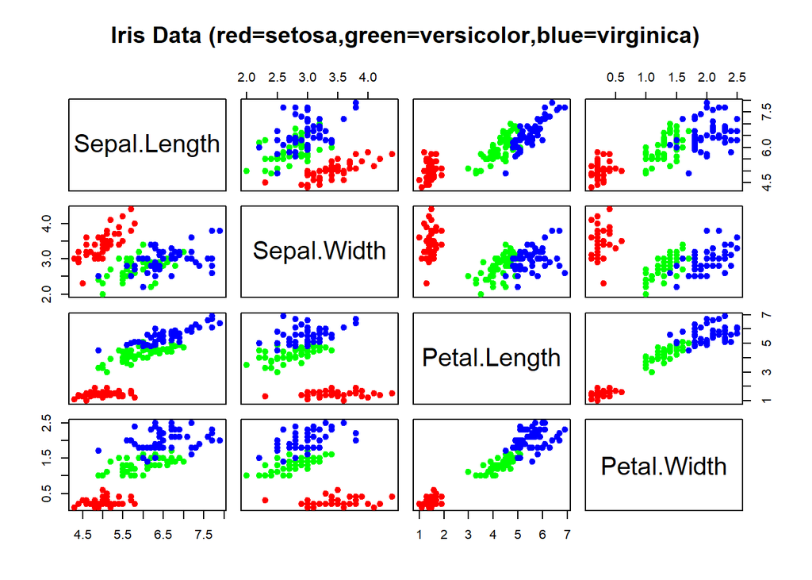

```r
#legend("bottomright",unique(species),col=myColors[species],pch=mySymbols[species]);  # why is legend not working?




# final answer using plot
myColors = c("red","green","blue");
mySymbols = c(19, 19, 19);
species = as.numeric(iris[,5]);
plot( iris[,-5],
      col=myColors[species],
      pch=mySymbols[species],
      main="Iris Data (red=setosa,green=versicolor,blue=virginica)"
    );
```

```r
# we need to add a caption into our final answer of our writeup ...  ALWAYS ...




# library(ggplot2);
# ggplot( iris,
#         aes(x=Sepal.Length,
#         color=Species)
#         )
#         + geom_density( )
#         + ggtitle("Main title")

# %>%

#ggplot(data = iris, aes( x = Sepal.Length, y = Sepal.Width,shape = Species, color = Species)) + geom_point()

# concept of scatterplot is different in ggplot than in plot
# this creates confusion, increases challenges to work effectively

# please share your solutions to this approach if it interests you?
# it doesn't interest me.  It is another entire syntax structure, I have
# already learned "plot" very well.  So if you want to choose to be an
# expert in this, so be it.





# final answer using ggplot

# I don't have a final answer personally here, this approach doesn't interest me.
# https://stackoverflow.com/questions/7721262/
# I agree with the Fredericko camp ... you may not and that is okay.
# Suggesting ggplot2 for "better graphics in R" is just so wrong. The standard R plotting functions have way more potential. – Federico Giorgi Mar 20 '14 at 5:52



library(dplyr);
library(tibble);

library(highcharter);
#install.packages("highcharter", dependencies=TRUE);


hcmap("https://code.highcharts.com/mapdata/countries/in/in-all.js")%>%
  hc_title(text = "India")
```

[interactive chart not shown]

```r
mapdata <- get_data_from_map(download_map_data("https://code.highcharts.com/mapdata/countries/in/in-all.js"))

glimpse(mapdata);
```

```
## Rows: 34
## Columns: 20
## $ `hc-group`    <chr> "admin1", "admin1", "admin1", "admin1", "admin1", "ad...
## $ `hc-middle-x` <dbl> 0.65, 0.59, 0.50, 0.56, 0.46, 0.46, 0.51, 0.59, 0.47,...
## $ `hc-middle-y` <dbl> 0.81, 0.63, 0.74, 0.38, 0.64, 0.51, 0.34, 0.41, 0.60,...
## $ `hc-key`      <chr> "in-py", "in-ld", "in-wb", "in-or", "in-br", "in-sk",...
## $ `hc-a2`       <chr> "PY", "LD", "WB", "OR", "BR", "SK", "CT", "TN", "MP",...
## $ labelrank     <chr> "2", "2", "2", "2", "2", "2", "2", "2", "2", "2", "2"...
## $ hasc          <chr> "IN.PY", "IN.LD", "IN.WB", "IN.OR", "IN.BR", "IN.SK",...
## $ `alt-name`    <chr> "Pondicherry|Puduchcheri|Pondichéry", "Íles Laquedive...
## $ `woe-id`      <chr> "20070459", "2345748", "2345761", "2345755", "2345742...
## $ fips          <chr> "IN22", "IN14", "IN28", "IN21", "IN34", "IN29", "IN37...
## $ `postal-code` <chr> "PY", "LD", "WB", "OR", "BR", "SK", "CT", "TN", "MP",...
## $ name          <chr> "Puducherry", "Lakshadweep", "West Bengal", "Orissa",...
## $ country       <chr> "India", "India", "India", "India", "India", "India",...
## $ `type-en`     <chr> "Union Territory", "Union Territory", "State", "State...
## $ region        <chr> "South", "South", "East", "East", "East", "East", "Ce...
## $ longitude     <chr> "79.7758", "72.7811", "87.7289", "84.4341", "85.8134"...
## $ `woe-name`    <chr> "Puducherry", "Lakshadweep", "West Bengal", "Orissa",...
## $ latitude      <chr> "10.9224", "11.2249", "23.0523", "20.625", "25.6853",...
## $ `woe-label`   <chr> "Puducherry, IN, India", "Lakshadweep, IN, India", "W...
## $ type          <chr> "Union Territor", "Union Territor", "State", "State",...
```

```r
str(mapdata);
```

```
## tibble [34 x 20] (S3: tbl_df/tbl/data.frame)
##  $ hc-group   : chr [1:34] "admin1" "admin1" "admin1" "admin1" ...
##  $ hc-middle-x: num [1:34] 0.65 0.59 0.5 0.56 0.46 0.46 0.51 0.59 0.47 0.56 ...
##  $ hc-middle-y: num [1:34] 0.81 0.63 0.74 0.38 0.64 0.51 0.34 0.41 0.6 0.32 ...
##  $ hc-key     : chr [1:34] "in-py" "in-ld" "in-wb" "in-or" ...
##  $ hc-a2      : chr [1:34] "PY" "LD" "WB" "OR" ...
##  $ labelrank  : chr [1:34] "2" "2" "2" "2" ...
##  $ hasc       : chr [1:34] "IN.PY" "IN.LD" "IN.WB" "IN.OR" ...
##  $ alt-name   : chr [1:34] "Pondicherry|Puduchcheri|Pondichéry" "Íles Laquedives|Laccadive|Minicoy and Amindivi Islands|Laccadives|Lackadiverna|Lakkadiven|Lakkadi" "Bangla|Bengala Occidentale|Bengala Ocidental|Bengale occidental" NA ...
##  $ woe-id     : chr [1:34] "20070459" "2345748" "2345761" "2345755" ...
##  $ fips       : chr [1:34] "IN22" "IN14" "IN28" "IN21" ...
##  $ postal-code: chr [1:34] "PY" "LD" "WB" "OR" ...
##  $ name       : chr [1:34] "Puducherry" "Lakshadweep" "West Bengal" "Orissa" ...
##  $ country    : chr [1:34] "India" "India" "India" "India" ...
##  $ type-en    : chr [1:34] "Union Territory" "Union Territory" "State" "State" ...
##  $ region     : chr [1:34] "South" "South" "East" "East" ...
##  $ longitude  : chr [1:34] "79.7758" "72.7811" "87.7289" "84.4341" ...
##  $ woe-name   : chr [1:34] "Puducherry" "Lakshadweep" "West Bengal" "Orissa" ...
##  $ latitude   : chr [1:34] "10.9224" "11.2249" "23.0523" "20.625" ...
##  $ woe-label  : chr [1:34] "Puducherry, IN, India" "Lakshadweep, IN, India" "West Bengal, IN, India" "Orissa, IN, India" ...
##  $ type       : chr [1:34] "Union Territor" "Union Territor" "State" "State" ...
```

```r
# unique(mapdata$`hc-group`);  # notice the "-" makes it a challenge to access...


#population state wise
pop = as.data.frame(c(84673556, 1382611, 31169272, 103804637, 1055450, 25540196, 342853, 242911, 18980000, 1457723, 60383628, 25353081, 6864602,
12548926, 32966238, 61130704, 33387677, 64429, 72597565, 112372972, 2721756, 2964007, 1091014, 1980602, 41947358, 1244464,
27704236, 68621012, 607688, 72138958, 3671032, 207281477, 10116752,91347736))

state= mapdata%>%
  select(`hc-a2`)%>%
  arrange(`hc-a2`)

State_pop = as.data.frame(c(state, pop))
names(State_pop)= c("State", "Population")

# why will hcmap not cache this?
hcmap("https://code.highcharts.com/mapdata/countries/in/in-all.js", data = State_pop, value = "Population",
      joinBy = c("hc-a2", "State"), name = "Fake data",
      dataLabels = list(enabled = TRUE, format = '{point.name}'),
      borderColor = "#FAFAFA", borderWidth = 0.1,
      tooltip = list(valueDecimals = 0))
```

[interactive chart not shown]

```r
# how hard is it to get real data ....
# can we use "zoom" option of highcharts?
# are there free web-page hosting
# http://md5.mshaffer.com/WSU_STATS419/cleanup.txt
# setup FTP to md5.mshaffer.com
# how to change where these are stored?

# the current highcharts wrapper `highcharter` can only be as good as the
# developer ...
# it builds the extra highcharts code in every instance, that should be stored i a local place
# it should build an options setup, so it can be developed as such ...
# JSON imports options, sets up data, more transparent ...
# use codepen or whatever to build the structure, apply as a JSON object and render ...
# pure javascript or JQUERY ...
# function buildHighChartsFromDataAndOptions(df, options)
# function buildOpenStreetMaps(df, options)

# Publish within RStudio to a public location ...
# what a mess ... they have collapse all "human-readable" storage structures
# you can't modify it further ...
# notice the vector of (x,y) coordinates to draw a polygon bounding box for each region ...

# viewer is a webpage ... how would it look in plain RGUI ...
# many highcharts are zoomable ... might be a parameter


 # it costs about $500 one-time for a single developer ...
 # I have bought it before ... it is a very nice tool and developer team
 # I have had exchanges with CEO in the forums, and have contributed code
 # to generic "highcharts" not highcharter
# webpage
 # so how do we put a HTML file as an interactive element in a webpage

# JSON PRETTY PRINT USING R


# In such scenarios, i follow Step1.require(jsonlite); json2 <- fromJSON(my_output, flatten = TRUE); Step2.library(dplyr); df <- as_data_frame(json2); – parth Jul 10 '17 at 10:15

# https://stackoverflow.com/questions/45153312/parsing-complex-json-into-dataframe-using-r




# final answer using highcharter
# Possibly rewrite as highchartsR library ...
```

```r
# https://www.kaggle.com/arshid/iris-flower-dataset
  # A common misconception is that this is the R.A. Fisher dataset of 1936.
  # I found the original dataset source, and that was a reading we had.
  # Kaggle is a useful resource, at times.  They have "notebooks" where people
  #   use python or R (or other language) to do analyses.

  # Python is an easier-syntaxed language, and many STATS package ideas
  #   are being "rewritten" in Python.  R is the original STATS package lang.

  # Python has some pre-built tools to get you started, such as ComputerVision


  # Useful on a project like this:
      # https://www.kaggle.com/c/passenger-screening-algorithm-challenge/notebooks
  # I used R to play with this dataset:  https://github.com/MonteShaffer/dhsEI
  # I also wrote some python code, somewhere.

  # This is a hard multi-variate data problem.
  #   CS people call it "machine-learning"

  # https://www.youtube.com/watch?v=y-ZCgbJVdBI
  #   This video does show something that looks like the raw scans,
  #     the raw scan is grabbed at 16 or more angles (spinning around your body)
  #     TSA has 17 zones (omitting the head for some reason) that they are
  #     looking for contraband ... https://bit.ly/33DNX28

  # My take from doing research:  they don't really work

  # Based on our "measure" project, they could easily measure an individual
  #   using some 3-D trigonmetry ... pixels convert to feet/cm
  #   with the exception of foot-length, they could capture your
  #   body profile easily.
```

# 3 Personality

## 3.1 Cleanup RAW

Import “personality-raw.txt” into R. Remove the V00 column. Create two new columns from the current column “date_test”: year and week. Stack Overflow may help: https://stackoverflow.com/questions/22439540/how-to-get-week-numbers-from-dates … Sort the new data frame by YEAR, WEEK so the newest tests are first … The newest tests (e.g., 2020 or 2019) are at the top of the data frame. Then remove duplicates using the unique function based on the column “md5_email”. Save the data frame in the same “pipe-delimited format” ( | is a pipe ) with the headers. You will keep the new data frame as “personality-clean.txt” for future work (you will not upload it at this time). In the homework, for this tasks, report how many records your raw dataset had and how many records your clean dataset has.

```r
# hackathon form:  http://md5.mshaffer.com/WSU_STATS419/cleanup.txt

#################################
# hackathon

# working directory is good-to-go

myFile = paste0(local.path,"datasets/personality/personality-raw.txt");

myData = read.csv(myFile,header=T,sep="|");



## subtask #1 (remove a column)
myData$V00 = NULL;  ## one method
myData["V00"] = NULL; ## equivalent ...  ****

#idx = which( names(myData)=="V00" );  ## second method
#myData = myData[,-c(idx)];

## subtask #2 (dates)  ... remove a column ...




#date.obj = strptime("5/17/2007 10:15", format="%m/%d/%Y %H:%M");
#my.year = as.numeric( strftime(date.obj, format='%Y') );
#my.week = as.numeric( strftime(date.obj, format='%W') );

myDate.obj = strptime(myData$date_test, format="%m/%d/%Y %H:%M");

myDate.obj.year = as.numeric( strftime(myDate.obj, format='%Y') );
myDate.obj.week = as.numeric( strftime(myDate.obj, format='%W') );

myData$year = myDate.obj.year;
myData$week = myDate.obj.week;

date.idx = which( names(myData)=="date_test" );



## remove date_test
myData["date_test"] = NULL;

# dim not length
df.dim = dim(myData);
df.pos = df.dim[2];

which( names(myData)=="year" );
```

```
## [1] 62
```

```r
which( names(myData)=="week" );
```

```
## [1] 63
```

```r
myData = myData[, c(1,62,63, 2:61)];

# date is at beginning
# 1, ... everything else
# date is after first
# 1:(date.idx-1)

if(date.idx == 1)
    {
    reorder = c( (df.pos-1):df.pos, 2:(df.pos-2) );
    } else  {
              reorder = c( 1:(date.idx-1), (df.pos-1):df.pos, 2:(df.pos-2) );
              }

myData = myData[, reorder];

myTest = myData[1:20,1:5];

myTest[ order(myTest[,3]), ];
```

|  | md5_email | V59 | V60 | year | week |
| --- | --- | --- | --- | --- | --- |
| 10 | b62c73cdaf59e0a13de495b84030734e | 4.04 | 2.12 | 2007 | 21 |
| 11 | b62c73cdaf59e0a13de495b84030734e | 4.04 | 2.12 | 2007 | 21 |
| 12 | d41d8cd98f00b204e9800998ecf8427e | 4.04 | 2.12 | 2007 | 21 |
| 4 | b62c73cdaf59e0a13de495b84030734e | 2.60 | 2.60 | 2007 | 20 |
| 5 | b62c73cdaf59e0a13de495b84030734e | 2.60 | 2.60 | 2007 | 20 |
| 6 | d41d8cd98f00b204e9800998ecf8427e | 2.60 | 2.60 | 2007 | 20 |
| 15 | defa931525e65cf19f8c98dd8fd65092 | 3.40 | 2.60 | 2007 | 21 |
| 16 | 8079cf5dc2c1a246c57363b43537cafb | 1.80 | 2.60 | 2007 | 22 |
| 17 | 8079cf5dc2c1a246c57363b43537cafb | 1.80 | 2.60 | 2007 | 22 |
| 7 | b62c73cdaf59e0a13de495b84030734e | 5.00 | 3.40 | 2007 | 21 |

[output cut: 10 more lines]

```r
myTest[ order(-myTest[,3]), ];
```

|  | md5_email | V59 | V60 | year | week |
| --- | --- | --- | --- | --- | --- |
| 14 | 6cf8ce0036738815722b48adc56f5bc0 | 4.20 | 5.00 | 2007 | 25 |
| 19 | 42235880933cfbca2103b1b5cb22b5bb | 5.00 | 5.00 | 2007 | 22 |
| 1 | b62c73cdaf59e0a13de495b84030734e | 3.40 | 4.20 | 2007 | 20 |
| 2 | b62c73cdaf59e0a13de495b84030734e | 3.40 | 4.20 | 2007 | 20 |
| 3 | d41d8cd98f00b204e9800998ecf8427e | 3.40 | 4.20 | 2007 | 20 |
| 13 | ff6bb9483e26768daa550d3a0debbe40 | 3.40 | 4.20 | 2007 | 21 |
| 18 | fc3aef1d8f6032d7b5267ee40a606f49 | 2.60 | 4.20 | 2007 | 22 |
| 20 | 1a100328bfa3acd6195c6094835316e0 | 1.80 | 4.20 | 2007 | 22 |
| 7 | b62c73cdaf59e0a13de495b84030734e | 5.00 | 3.40 | 2007 | 21 |
| 8 | b62c73cdaf59e0a13de495b84030734e | 5.00 | 3.40 | 2007 | 21 |

[output cut: 10 more lines]

```r
myData.sorted = myData[ order(-myData[,date.idx],-myData[,(1+date.idx)]), ];

head(myData.sorted[,1:5]);
```

|  | md5_email | V59 | V60 | year | week |
| --- | --- | --- | --- | --- | --- |
| 19 | 42235880933cfbca2103b1b5cb22b5bb | 5 | 5 | 2007 | 22 |
| 28 | cb916b1a2f0428f21335bf12f59641e2 | 5 | 5 | 2007 | 23 |
| 61 | 1664a456689f5602bb6954eb897e423e | 5 | 5 | 2008 | 13 |
| 65 | ade6e800f168cc2e638538cef9e6e9a6 | 5 | 5 | 2008 | 20 |
| 76 | 1664a456689f5602bb6954eb897e423e | 5 | 5 | 2008 | 27 |
| 86 | 72707bb71794071355aa539019e040ea | 5 | 5 | 2008 | 27 |

```r
u = unique( myData.sorted["md5_email"] );

myData.cleansed = myData.sorted[!duplicated(myData.sorted["md5_email"]), ];

 dim(myData.sorted);
```

```
## [1] 838  63
```

```r
 dim(myData.cleansed);
```

```
## [1] 678  63
```

```r
# newFile = paste0(local.path,"datasets/personality/personality-clean.txt");
# write.table( myData.cleansed , file=newFile, quote=FALSE, col.names=TRUE, row.names=FALSE, sep="|");
```

```r
# v1 of humanVerseWSU form:  http://md5.mshaffer.com/WSU_STATS419/cleanup2.txt

myFile = paste0(local.path,"datasets/personality/personality-raw.txt");
df = read.csv(myFile,header=T,sep="|");


  df = removeColumnsFromDataFrame(df, "V00");

date.formats = c("year","week","day");
   vec = df$date_test;
year = convertDateStringToFormat(vec,"%Y","%m/%d/%Y %H:%M");
week = convertDateStringToFormat(vec,"%W","%m/%d/%Y %H:%M");
day  = convertDateStringToFormat(vec,"%j","%m/%d/%Y %H:%M");
   newcols = cbind(year,week,day);
     colnames(newcols) = date.formats;

ndf = replaceDateStringWithDateColumns(df,"date_test",newcols);
ndf = sortDataFrameByNumericColumns(ndf, date.formats, "DESC");
ndf = removeDuplicatesFromDataFrame(ndf, "md5_email");

ndf;
```

|  | md5_email | year | week | day | V01 | V02 | V03 | V04 | V05 | V06 | V07 | V08 | V09 | V10 | V11 | V12 | V13 | V14 | V15 | V16 | V17 | V18 | V19 | V20 | V21 | V22 | V23 | V24 | V25 | … |
| --- | --- | --- | --- | --- | --- | --- | --- | --- | --- | --- | --- | --- | --- | --- | --- | --- | --- | --- | --- | --- | --- | --- | --- | --- | --- | --- | --- | --- | --- | --- |
| 1 | b62c73cdaf59e0a13de495b84030734e | NA | NA | NA | 4.2 | 1.8 | 1.8 | 2.6 | 3.4 | 5.0 | 2.6 | 2.6 | 1.8 | 1.8 | 1.8 | 1.8 | 5.0 | 4.2 | 1.8 | 1.8 | 1.8 | 1.0 | 2.6 | 3.4 | 1.8 | 1.8 | 2.6 | 1.8 | 3.4 | … |
| 3 | d41d8cd98f00b204e9800998ecf8427e | NA | NA | NA | 4.2 | 1.8 | 1.8 | 2.6 | 3.4 | 5.0 | 2.6 | 2.6 | 1.8 | 1.8 | 1.8 | 1.8 | 5.0 | 4.2 | 1.8 | 1.8 | 1.8 | 1.0 | 2.6 | 3.4 | 1.8 | 1.8 | 2.6 | 1.8 | 3.4 | … |
| 13 | ff6bb9483e26768daa550d3a0debbe40 | NA | NA | NA | 2.6 | 3.4 | 1.8 | 2.6 | 2.6 | 5.0 | 3.4 | 2.6 | 2.6 | 4.2 | 3.4 | 2.6 | 4.2 | 3.4 | 2.6 | 3.4 | 1.8 | 2.6 | 4.2 | 1.8 | 2.6 | 4.2 | 5.0 | 4.2 | 4.2 | … |
| 14 | 6cf8ce0036738815722b48adc56f5bc0 | NA | NA | NA | 2.6 | 5.0 | 3.4 | 4.2 | 4.2 | 4.2 | 3.4 | 5.0 | 5.0 | 4.2 | 4.2 | 3.4 | 4.2 | 3.4 | 5.0 | 4.2 | 4.2 | 4.2 | 4.2 | 3.4 | 4.2 | 3.4 | 4.2 | 4.2 | 2.6 | … |
| 15 | defa931525e65cf19f8c98dd8fd65092 | NA | NA | NA | 4.2 | 4.2 | 1.8 | 4.2 | 3.4 | 3.4 | 3.4 | 3.4 | 4.2 | 4.2 | 3.4 | 3.4 | 3.4 | 3.4 | 3.4 | 4.2 | 3.4 | 3.4 | 4.2 | 3.4 | 4.2 | 1.8 | 4.2 | 3.4 | 4.2 | … |
| 16 | 8079cf5dc2c1a246c57363b43537cafb | NA | NA | NA | 4.2 | 2.6 | 1.8 | 1.8 | 4.2 | 2.6 | 2.6 | 2.6 | 2.6 | 2.6 | 2.6 | 1.8 | 1.8 | 2.6 | 2.6 | 2.6 | 4.2 | 4.2 | 1.8 | 4.2 | 2.6 | 2.6 | 4.2 | 2.6 | 3.4 | … |
| 18 | fc3aef1d8f6032d7b5267ee40a606f49 | NA | NA | NA | 5.0 | 4.2 | 1.8 | 3.4 | 3.4 | 5.0 | 4.2 | 5.0 | 4.2 | 3.4 | 2.6 | 3.4 | 3.4 | 2.6 | 4.2 | 4.2 | 5.0 | 5.0 | 1.8 | 1.8 | 2.6 | 3.4 | 4.2 | 4.2 | 2.6 | … |
| 19 | 42235880933cfbca2103b1b5cb22b5bb | NA | NA | NA | 3.4 | 5.0 | 1.0 | 5.0 | 4.2 | 4.2 | 4.2 | 4.2 | 5.0 | 5.0 | 5.0 | 5.0 | 5.0 | 5.0 | 3.4 | 4.2 | 5.0 | 5.0 | 4.2 | 5.0 | 5.0 | 5.0 | 5.0 | 4.2 | 4.2 | … |
| 20 | 1a100328bfa3acd6195c6094835316e0 | NA | NA | NA | 2.6 | 1.0 | 5.0 | 3.4 | 4.2 | 4.2 | 3.4 | 3.4 | 2.6 | 2.6 | 1.8 | 1.8 | 1.8 | 1.0 | 4.2 | 2.6 | 4.2 | 3.4 | 2.6 | 3.4 | 1.0 | 2.6 | 3.4 | 4.2 | 2.6 | … |
| 21 | 9fd7f7de826c3a166a7b80ba10ffc1f6 | NA | NA | NA | 2.6 | 2.6 | 2.6 | 4.2 | 4.2 | 3.4 | 3.4 | 3.4 | 4.2 | 3.4 | 3.4 | 2.6 | 2.6 | 3.4 | 3.4 | 3.4 | 3.4 | 3.4 | 1.8 | 1.8 | 2.6 | 3.4 | 2.6 | 3.4 | 2.6 | … |

[output cut: 668 more lines]

```r
dim(df);  # 838
```

```
## [1] 838  62
```

```r
dim(ndf); # 678
```

```
## [1] 678  64
```

```r
# newFile = paste0(local.path,"datasets/personality/personality-clean.txt");
# write.table( ndf , file=newFile, quote=FALSE, col.names=TRUE, row.names=FALSE, sep="|");



# my latest version of these functions will simplify the "date-manipulation"
#     to just one function
```

# 4 Variance and Z-scores

Write functions for doSummary and sampleVariance and doMode … test these functions in your homework on the “monte.shaffer@gmail.com” record from the clean dataset. Report your findings. For this “monte.shaffer@gmail.com” record, also create z-scores. Plot(x,y) where x is the raw scores for “monte.shaffer@gmail.com” and y is the z-scores from those raw scores. Include the plot in your assignment, and write 2 sentences describing what pattern you are seeing and why this pattern is present.

```r
library(humanVerseWSU);
#?doStatsSummary

# I ended up renaming my function doStatsSummary, I wanted to replace the
#   limited data found in ?summary for some (not sum) time.

x.norm = rnorm(100,0,1);
s.norm = doStatsSummary ( x.norm );
str(s.norm);  # mode is pretty meaningless on this data
```

```
## List of 32
##  $ length           : int 100
##  $ length.na        : int 0
##  $ length.good      : int 100
##  $ mean             : num -0.115
##  $ mean.trim.05     : num -0.107
##  $ mean.trim.20     : num -0.0906
##  $ median           : num -0.119
##  $ MAD              : num 1.05
##  $ IQR              : num 1.36
##  $ quartiles        : Named num [1:3] -0.776 -0.119 0.586
##   ..- attr(*, "names")= chr [1:3] "25%" "50%" "75%"
##  $ deciles          : Named num [1:9] -1.415 -0.901 -0.669 -0.389 -0.119 ...
##   ..- attr(*, "names")= chr [1:9] "10%" "20%" "30%" "40%" ...
##  $ centiles         : Named num [1:99] -2.77 -2.42 -1.9 -1.72 -1.71 ...
##   ..- attr(*, "names")= chr [1:99] "1%" "2%" "3%" "4%" ...
##  $ median.weighted  : num 1.05
##  $ MAD.weighted     : num -0.119
##  $ max              : num 2.17
##  $ min              : num -2.83
##  $ range            : num 5.01
##  $ xlim             : num [1:2] -2.83 2.17
##  $ max.idx          : num 75
##  $ min.idx          : num 46
##  $ freq.max         : num [1:100] -2.83 -2.77 -2.42 -1.88 -1.72 ...
##  $ mode             : num [1:100] -2.83 -2.77 -2.42 -1.88 -1.72 ...
##  $ which.min.freq   : num [1:100] -2.83 -2.77 -2.42 -1.88 -1.72 ...
##  $ ylim             : int [1:2] 1 1
##  $ sd               : num 1.02
##  $ var              : num 1.05
##  $ var.naive        :List of 3
##   ..$ x.bar: num -0.115
##   ..$ s.var: num 1.05
##   ..$ s.sd : num 1.02
##  $ var.2step        :List of 3
##   ..$ x.bar: num -0.115
##   ..$ s.var: num 1.05
##   ..$ s.sd : num 1.02
##  $ shapiro          :List of 4
##   ..$ statistic: Named num 0.991
##   .. ..- attr(*, "names")= chr "W"
##   ..$ p.value  : num 0.718
##   ..$ method   : chr "Shapiro-Wilk normality test"
##   ..$ data.name: chr "xx"
##   ..- attr(*, "class")= chr "htest"
##  $ shapiro.is.normal:List of 3
##   ..$ 0.10: logi TRUE
##   ..$ 0.05: logi TRUE
##   ..$ 0.01: logi TRUE
##  $ outliers.z       :'data.frame':   0 obs. of  2 variables:
##   ..$ value    : chr(0)
##   ..$ direction: chr(0)
##  $ outliers.IQR     :'data.frame':   1 obs. of  3 variables:
##   ..$ value    : chr "-2.83257078743146"
##   ..$ fence    : chr "inner"
##   ..$ direction: chr "lower"
```

```r
x.unif = runif(100,0,1);
s.unif = doStatsSummary ( x.unif );
str(s.unif);  # mode is pretty meaningless on this data
```

```
## List of 32
##  $ length           : int 100
##  $ length.na        : int 0
##  $ length.good      : int 100
##  $ mean             : num 0.481
##  $ mean.trim.05     : num 0.479
##  $ mean.trim.20     : num 0.472
##  $ median           : num 0.447
##  $ MAD              : num 0.361
##  $ IQR              : num 0.482
##  $ quartiles        : Named num [1:3] 0.216 0.447 0.697
##   ..- attr(*, "names")= chr [1:3] "25%" "50%" "75%"
##  $ deciles          : Named num [1:9] 0.113 0.181 0.276 0.405 0.447 ...
##   ..- attr(*, "names")= chr [1:9] "10%" "20%" "30%" "40%" ...
##  $ centiles         : Named num [1:99] 0.00616 0.01323 0.02535 0.0308 0.03191 ...
##   ..- attr(*, "names")= chr [1:99] "1%" "2%" "3%" "4%" ...
##  $ median.weighted  : num 0.361
##  $ MAD.weighted     : num 0.447
##  $ max              : num 0.988
##  $ min              : num 0.0045
##  $ range            : num 0.984
##  $ xlim             : num [1:2] 0.0045 0.9883
##  $ max.idx          : num 100
##  $ min.idx          : num 24
##  $ freq.max         : num [1:100] 0.0045 0.00618 0.01338 0.02572 0.03101 ...
##  $ mode             : num [1:100] 0.0045 0.00618 0.01338 0.02572 0.03101 ...
##  $ which.min.freq   : num [1:100] 0.0045 0.00618 0.01338 0.02572 0.03101 ...
##  $ ylim             : int [1:2] 1 1
##  $ sd               : num 0.291
##  $ var              : num 0.0844
##  $ var.naive        :List of 3
##   ..$ x.bar: num 0.481
##   ..$ s.var: num 0.0844
##   ..$ s.sd : num 0.291
##  $ var.2step        :List of 3
##   ..$ x.bar: num 0.481
##   ..$ s.var: num 0.0844
##   ..$ s.sd : num 0.291
##  $ shapiro          :List of 4
##   ..$ statistic: Named num 0.955
##   .. ..- attr(*, "names")= chr "W"
##   ..$ p.value  : num 0.00182
##   ..$ method   : chr "Shapiro-Wilk normality test"
##   ..$ data.name: chr "xx"
##   ..- attr(*, "class")= chr "htest"
##  $ shapiro.is.normal:List of 3
##   ..$ 0.10: logi FALSE
##   ..$ 0.05: logi FALSE
##   ..$ 0.01: logi FALSE
##  $ outliers.z       :'data.frame':   0 obs. of  2 variables:
##   ..$ value    : chr(0)
##   ..$ direction: chr(0)
##  $ outliers.IQR     :'data.frame':   0 obs. of  3 variables:
##   ..$ value    : chr(0)
##   ..$ fence    : chr(0)
##   ..$ direction: chr(0)
```

```r
# https://raw.githubusercontent.com/MonteShaffer/humanVerseWSU/master/humanVerseWSU/R/functions-stats.R
# https://raw.githubusercontent.com/MonteShaffer/humanVerseWSU/master/humanVerseWSU/R/functions-vector.R

#################################################################

doStatsSummary = function(x)
    {
    result = list();
        result$length = length(x);
    xx = stats::na.omit(x);
        result$length.na = length(x) - length(xx);
        result$length.good = length(xx);
    result$mean = mean(xx);
    result$mean.trim.05 = mean(xx, trim=0.05);
    result$mean.trim.20 = mean(xx, trim=0.20);

    result$median = stats::median(xx);
    result$MAD = stats::mad(xx);
    result$IQR = stats::IQR(xx);
    result$quartiles = stats::quantile(xx, prob=c(.25,.5,.75));
    result$deciles = stats::quantile(xx, prob=seq(0.1,0.9,by=0.1) );
    result$centiles = stats::quantile(xx, prob=seq(0.01,0.99,by=0.01) );

    result$median.weighted = matrixStats::weightedMad(xx);
    result$MAD.weighted = matrixStats::weightedMedian(xx);

    result$max = max(xx);
    result$min = min(xx);
    result$range = result$max - result$min;
    result$xlim = range(xx);

    result$max.idx = whichMax(x);
    result$min.idx = whichMin(x);

    result$mode = result$freq.max = doMode(x);  # elements with highest frequency
    result$which.min.freq = doModeOpposite(x);

    result$ylim = c( freqMin(xx), freqMax(xx) );

    # you could later get indexes of each mode(freq.max)/freq.min using findAllIndexesWithValueInVector

    result$sd = stats::sd(xx);
    result$var = stats::var(xx);

    result$var.naive = doSampleVariance(x,"naive");
    result$var.2step = doSampleVariance(x,"2step");


    ## normality
    result$shapiro = stats::shapiro.test(xx);
    result$shapiro.is.normal = list("0.10" = isTRUE(result$shapiro$p.value > 0.10), "0.05" = isTRUE(result$shapiro$p.value > 0.05), "0.01" = isTRUE(result$shapiro$p.value > 0.01) );

    result$outliers.z = findOutliersUsingZscores(x);
    result$outliers.IQR = findOutliersUsingIQR(x);

    #result$z = calculateZscores(x);

    result;
  }

#################################################################

doSampleVariance = function(x, method="two-pass")
    {
    x = stats::na.omit(x);
    if(method=="naive")
        {
        n = 0;
        sum = 0;
        sum2 = 0;

        for(i in 1:length(x))  ## stats::na.omit(x)
            {
            n = n + 1;
            sum = sum + x[i];
            sum2 = sum2 + x[i]*x[i];
            }

        if(n < 2) { return(NULL);} #
            x.bar = sum/n;
            s.var = (sum2 - (sum*sum)/n)/(n-1);

        } else  {
                # two-pass algorithm # testing
                n = sum = sum2 = 0;
                ## first pass
                for(i in 1:length(x))  ## stats::na.omit(x)
                    {
                    n = n + 1;
                    sum = sum + x[i];
                    }
        if(n < 2) { return(NULL);} #
                x.bar = sum/n;
                ## second pass
                for(i in 1:length(x))  ## stats::na.omit(x)
                    {
                    deviation = x[i] - x.bar;
                    sum2 = sum2 + deviation * deviation;
                    }
                s.var = sum2/(n-1);
                }

        s.sd = sqrt(s.var);
    list("x.bar"=x.bar,"s.var"=s.var,"s.sd"=s.sd);
    }

#################################################################

doMode = function(x) # alias ?
    {
    whichMaxFreq(x);
  }


whichMaxFreq = function(x)  # doMode
    {
    x.table = as.data.frame( table(x) );
        freq.max = max( x.table$Freq );
    x.list = x.table[x.table$Freq==freq.max,];
    xs = as.numeric( as.vector (x.list$x) );
    xs;
    }

# R does not have a "mode" function built in that will capture ties.
#   This function will.
# In the process, I wrote other functions that are also not robust in R.
# For example ?which.max versus my function ?whichMax

which.max( c(87, presidents[1:30], 87) );
```

```
## [1] 1
```

```r
whichMax( c(87, presidents[1:30], 87) );
```

```
## [1]  1  3 32
```

```r
## a function can also be referenced using class::method notation

base::which.max( c(87, presidents[1:30], 87) );
```

```
## [1] 1
```

```r
#humanVerseWUS::whichMax( c(87, presidents[1:30], 87) );

# typos ...
humanVerseWSU::whichMax( c(87, presidents[1:30], 87) );
```

```
## [1]  1  3 32
```

```r
## this will prevent confusion if functions have the same name (in different packages)

#################################################################

# not a requirement for your homework, but here is a function that will do it.
calculateZscores = function(x, x.bar=NULL, s.hat=NULL)
    {
  if(is.numeric(x.bar) && is.numeric(s.hat)) { return ((x - x.bar) / s.hat);}
  # maybe throw a warning if one is null, but not the other
  if( (is.null(x.bar) + is.null(s.hat)) == 1)
      {
      warning("Only one value was entered for x.bar / s.hat ... Computing these values instead.")
      }


    dsv = doSampleVariance(x);

    x.bar = dsv$x.bar;
    s.hat = dsv$s.sd;

    if(is.null(s.hat)) { return (NULL); }  # we take care of division by zero in our custom sampleVarianceFunction

    (x - x.bar) / s.hat;
    }
```

## 4.1 Variance

### 4.1.1 Naive

```r
# https://raw.githubusercontent.com/MonteShaffer/humanVerseWSU/master/humanVerseWSU/R/functions-standardize.R

v.norm = doSampleVariance(x.norm, "naive");


# if x is really small
vsmall.df = as.data.frame( t(unlist(v.norm)) );

x.small = x.norm;
for(i in 1:20)
  {
  # every loop make it 1000 times smaller
  # notice I am looping over "i" but not using it.
  x.small = standardizeToFactor(x.small, 1/1000);
  v.small = doSampleVariance(x.small, "naive");
    v.row = t(unlist(v.small));
  vsmall.df = rbind(vsmall.df, v.row);
  }

vsmall.df;
```

| x.bar | s.var | s.sd |
| --- | --- | --- |
| -1.151777e-01 | 1.048671e+00 | 1.024046e+00 |
| -1.151777e-04 | 1.048671e-06 | 1.024046e-03 |
| -1.151777e-07 | 1.048671e-12 | 1.024046e-06 |
| -1.151777e-10 | 1.048671e-18 | 1.024046e-09 |
| -1.151777e-13 | 1.048671e-24 | 1.024046e-12 |
| -1.151777e-16 | 1.048671e-30 | 1.024046e-15 |
| -1.151777e-19 | 1.048671e-36 | 1.024046e-18 |
| -1.151777e-22 | 1.048671e-42 | 1.024046e-21 |
| -1.151777e-25 | 1.048671e-48 | 1.024046e-24 |
| -1.151777e-28 | 1.048671e-54 | 1.024046e-27 |

[output cut: 11 more lines]

```r
# if x is really big
vlarge.df = as.data.frame( t(unlist(v.norm)) );

x.large = x.norm;
for(i in 1:20)
  {
  # every loop make it 1000 times larger
  # notice I am looping over "i" but not using it.
  x.large = standardizeToFactor(x.large, 1000);
  v.large = doSampleVariance(x.large, "naive");
    v.row = t(unlist(v.large));
  vlarge.df = rbind(vlarge.df, v.row);
  }

vlarge.df;
```

| x.bar | s.var | s.sd |
| --- | --- | --- |
| -1.151777e-01 | 1.048671e+00 | 1.024046e+00 |
| -1.151777e+02 | 1.048671e+06 | 1.024046e+03 |
| -1.151777e+05 | 1.048671e+12 | 1.024046e+06 |
| -1.151777e+08 | 1.048671e+18 | 1.024046e+09 |
| -1.151777e+11 | 1.048671e+24 | 1.024046e+12 |
| -1.151777e+14 | 1.048671e+30 | 1.024046e+15 |
| -1.151777e+17 | 1.048671e+36 | 1.024046e+18 |
| -1.151777e+20 | 1.048671e+42 | 1.024046e+21 |
| -1.151777e+23 | 1.048671e+48 | 1.024046e+24 |
| -1.151777e+26 | 1.048671e+54 | 1.024046e+27 |

[output cut: 11 more lines]

```r
## from these two experiments it looks okay!

## CS purists say it will fail eventually
## maybe I have to use a smaller n to demo failure?

## examine the function , the failure point is:    sum2 = sum2 + x[i]*x[i];
## [+5 Easter to first x-vec of 100 numbers that causes "naive" to fail!]
## by fail, I mean the "two-pass" approach and built ?sd or ?var function
## shows something entirely different ...
```

#### 4.1.1.1 Problems with this approach

### 4.1.2 Traditional Two Pass

```r
v2.norm = doSampleVariance(x.norm, "two-pass");
v2b.norm = doSampleVariance(x.norm);  # default value is "two-pass" in the function
v2c.norm = doSampleVariance(x.norm, "garblideljd=-gook"); # if logic defaults to "two-pass"

unlist(v2.norm);
```

```
##      x.bar      s.var       s.sd
## -0.1151777  1.0486712  1.0240465
```

```r
unlist(v2b.norm);
```

```
##      x.bar      s.var       s.sd
## -0.1151777  1.0486712  1.0240465
```

```r
unlist(v2c.norm);
```

```
##      x.bar      s.var       s.sd
## -0.1151777  1.0486712  1.0240465
```

## 4.2 Z-Scores

Application of z-score

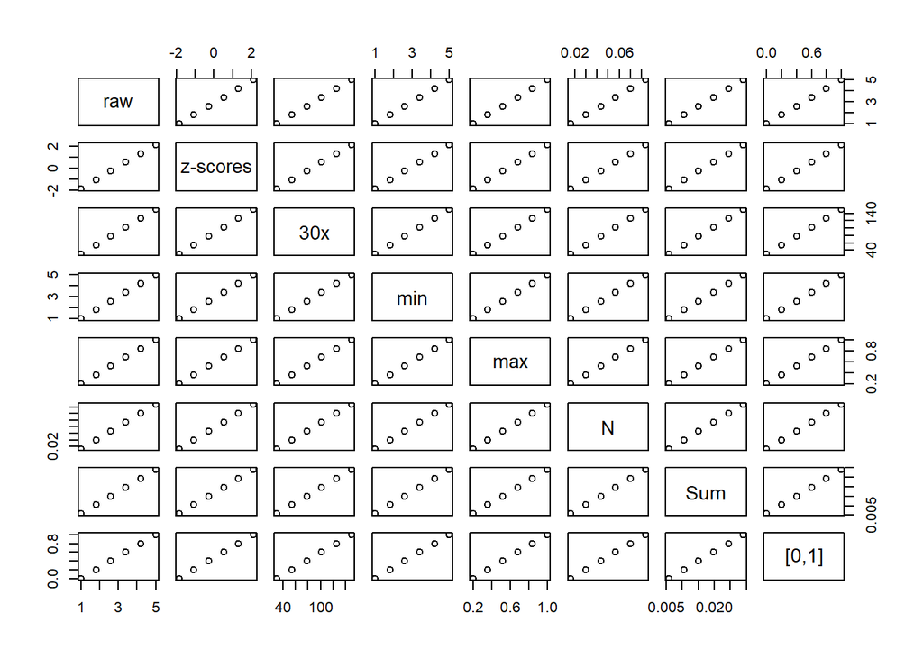

```r
# the built in function ?scale you should find useful.
# a z-score is taken on a vector of data requires x.bar and s.hat
# generally, we assume x.bar and s.hat comes from the vector of data.
# It doesn't have to.

library(digest);
md5_monte = digest("monte.shaffer@gmail.com", algo="md5");  # no workee???
md5_monte = "b62c73cdaf59e0a13de495b84030734e";

# jQuery [b62c73cdaf59e0a13de495b84030734e]     https://www.jqueryscript.net/demo/MD5-Hash-String/
# Javascript [b62c73cdaf59e0a13de495b84030734e] http://md5.mshaffer.com/
# PHP     [b62c73cdaf59e0a13de495b84030734e]    https://onlinegdb.com/rJUGCTkrw
# Python enthusiasts:  I recommend WingIDE  ... https://wingware.com/
# [+5 investigate the issue... write a Python function that passes in a string
#   and returns a md5 string, write an onlinegdb.com example for C,
#   and write an onlinegdb.com example for C++ ... summarize your findings.]

row = ndf[ndf$md5_email == md5_monte, ];
vec.start = getIndexOfDataFrameColumns(row,"V01");  # 5
vec.end = getIndexOfDataFrameColumns(row,"V60"); # 64

vec = as.numeric( row[vec.start:vec.end] );  # vector functions require "vector form"
# recall the concept of a vector basis? (e.g., basis of vector space)
# linear combinations of this basis?


vdf = as.data.frame( t(vec) );  # dim(vdf) tells me to transpose it.
  myRows = c("raw");

z.vec = calculateZscores(vec);
  vdf = rbind(vdf,z.vec);     myRows=c(myRows,"z-scores");

z.vec30 = standardizeToFactor(vec, 30);
  vdf = rbind(vdf,z.vec30);  myRows=c(myRows,"30x");

z.vecmin = standardizeToMin(vec);  # like z-scores, should rewrite to allow it be passed in, by default it computes
  vdf = rbind(vdf,z.vecmin);  myRows=c(myRows,"min");

z.vecmax = standardizeToMax(vec);  # like z-scores, should rewrite to allow it be passed in, by default it computes
  vdf = rbind(vdf,z.vecmax);  myRows=c(myRows,"max");

z.vecN = standardizeToN(vec);  # like z-scores, should rewrite to allow it be passed in, by default it computes
  vdf = rbind(vdf,z.vecN);  myRows=c(myRows,"N");

z.vecSum = standardizeToSum (vec);  # like z-scores, should rewrite to allow it be passed in, by default it computes
  vdf = rbind(vdf,z.vecSum);  myRows=c(myRows,"Sum");

z.vecBound = standardizeFromOneRangeToAnother(vec, c(0,1) );  # like z-scores, should rewrite to allow it be passed in, by default it computes
  vdf = rbind(vdf,z.vecBound);  myRows=c(myRows,"[0,1]");

rownames(vdf) = myRows;

tvdf = as.data.frame( t(vdf) ); # why transpose it?

graphics::plot( tvdf );
```

```r
# linear transformations are "linear" ... should not be surprising
# how does perfect linearity relate to "correlation"?

# Multiplying by a negative number (not shown) is also a vector-basis manipulation.
# As is rotating by an angle.
# What is an example of a nonlinear combination?
# Hint look at your will/denzel problem.
# plot(will$movies.50[,c(1,6,7:10)]); ... one relationship is strong, nonlinear
```

# 5 Will vs Denzel

```r
#source( paste0(local.path,"functions/functions-imdb.R"), local=T );

# some of you were having issues with the IMDB web connection.
# I was annoyed rvest doesn't cache ...
# here is a hack ... using dput

# http://md5.mshaffer.com/WSU_STATS419/denzel
# http://md5.mshaffer.com/WSU_STATS419/will

# I will be building out a IMDB dataset for our use to perform multivariate analyses
# without relying on IMDB ...
```

Compare Will Smith and Denzel Washington. [See 03_n greater 1-v2.txt for the necessary functions and will-vs-denzel.txt for some sample code and in DROPBOX: __student_access___01_exploratory_data_analysis_02-example ] You will have to create a new variable $millions.2000 that converts each movie’s $millions based on the $year of the movie, so all dollars are in the same time frame. You will need inflation data from about 1980-2020 to make this work.

## 5.1 Will Smith

```r
nmid = "nm0000226";
    #will = grabFilmsForPerson(nmid);  ## can we source for dput?
  source_url("http://md5.mshaffer.com/WSU_STATS419/will");  # look at syntax
```

```
## SHA-1 hash of file is 3c1c97d961577e9b47a12faa20dca74bfe755c87
```

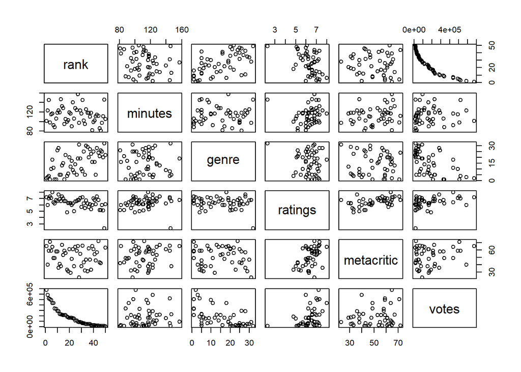

Will Smith scatterplot: IMDB(2020)

```r
                                                            # will = data;

    plot(will$movies.50[,c(1,6,7:10)]);
```

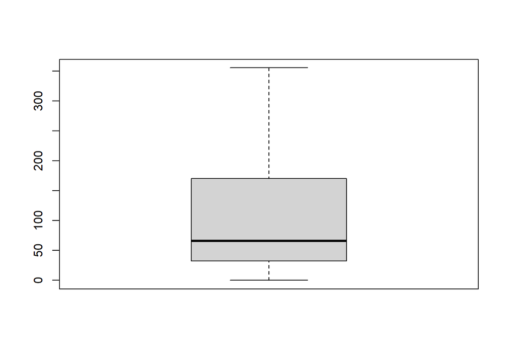

Will Smith boxplot raw millions: IMDB(2020)

```r
    boxplot(will$movies.50$millions);
```

```r
        widx =  which.max(will$movies.50$millions);
    will$movies.50[widx,];
```

|  | rank | title | ttid | year | rated | minutes | genre | ratings | metacritic | votes | millions |
| --- | --- | --- | --- | --- | --- | --- | --- | --- | --- | --- | --- |
| 15 | 15 | Aladdin | tt6139732 | 2019 | PG | 128 | Adventure, Family, Fantasy | 7 | 53 | 216296 | 355.56 |

```r
        summary(will$movies.50$year);  # bad boys for life ... did data change?
```

```
##    Min. 1st Qu.  Median    Mean 3rd Qu.    Max.
##    1993    2001    2006    2007    2014    2020
```

```r
nmid = "nm0000243";
    #denzel = grabFilmsForPerson(nmid);  ## can we source for dput?
  source_url("http://md5.mshaffer.com/WSU_STATS419/denzel");  # look at syntax
```

```
## SHA-1 hash of file is d70cfda5519a08daa44a22e88c68be1f7ee15729
```

[figure not shown]

```r
                                                            # denzel = data;

    plot(denzel$movies.50[,c(1,6,7:10)]);
```

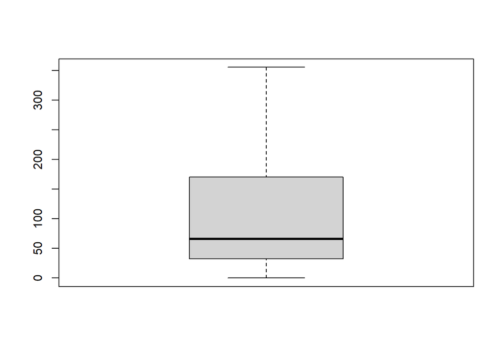

```r
    boxplot(denzel$movies.50$millions);
```

```r
        didx =  which.max(denzel$movies.50$millions);
    denzel$movies.50[didx,];
```

[output not shown]

```r
        summary(denzel$movies.50$year);
```

```
##    Min. 1st Qu.  Median    Mean 3rd Qu.    Max.
##    1993    2001    2006    2007    2014    2020
```

## 5.3 BoxPlot of Top-50 movies using Raw Dollars

[figure not shown]

```r
par(mfrow=c(1,2));
    boxplot(will$movies.50$millions, main=will$name, ylim=c(0,360), ylab="Raw Millions" );
    boxplot(denzel$movies.50$millions, main=denzel$name, ylim=c(0,360), ylab="Raw Millions" );
```

```r
    par(mfrow=c(1,1));
```

## 5.4 Side-by-Side Comparisons

Build side-by-side box plots on several of the variables (including #6) to compare the two movie stars. After each box plot, write 2+ sentence describing what you are seeing, and what conclusions you can logically make. You will need to review what the box plot is showing with the box portion, the divider in the box, and the whiskers.

```r
# creating a graphics or plot notebook with example chunks of code would benefit you.
# Since we have multiple variables, I would look into ?stars
# You could possibly create an "index" (e.g., a weighted linear combination of
# the multivariate factors).  To capture "better" and "best", you have to analyze
# the sub-elements in the index.  Does "popular" mean "best"?  Look at stackoverflow,
# the most-popular questions, are they an indication of being best?

# a nice resource for some code samples and what plots look like are in the
# DROPBOX (added 8/28): \__student_access__\sample_latex_files\Multivariate-2009
# I will likely do a self-evaluation of these samples as an optional video at some point.
# Scan through the documents, look at visuals you like...
# Tangent, PAGE 7 of HW#3 has doSegments function which creates "error bars"

# ?stars :  maybe plot the median or mean values ... z-scored?
#           HW#2, Program#8;
#           HW#6, Program#2; ... and a few other places in this document


#  I could use raw values for the initial plots...
#  However, I may want to create z-scores ... "pooling" will and denzel data.
#  That way, the star charts will have the same scale and the z-scores
#  in a pooled fashion will get it to an "apples-to-apples" comparison.
#  An index of "betterness" with z-scores would be superior to a raw index.
#  Again, the quality of the index is the quality of the features defining it.
#  Is it a "better" index?  Or a "popular" index?
#  How could we objectively measure "better"?
```

### 5.4.1 Adjusted Dollars (2000)

```r
# https://raw.githubusercontent.com/MonteShaffer/humanVerseWSU/master/humanVerseWSU/R/functions-inflation.R

humanVerseWSU::loadInflationData();
str(denzel$movies.50);
```

```
## 'data.frame':    50 obs. of  11 variables:
##  $ rank      : num  1 2 3 4 5 6 7 8 9 10 ...
##  $ title     : chr  "I Am Legend" "Suicide Squad" "Independence Day" "Men in Black" ...
##  $ ttid      : chr  "tt0480249" "tt1386697" "tt0116629" "tt0119654" ...
##  $ year      : num  2007 2016 1996 1997 2004 ...
##  $ rated     : chr  "PG-13" "PG-13" "PG-13" "PG-13" ...
##  $ minutes   : num  101 123 145 98 115 117 92 88 106 118 ...
##  $ genre     : chr  "Action, Adventure, Drama" "Action, Adventure, Fantasy" "Action, Adventure, Sci-Fi" "Action, Adventure, Comedy" ...
##  $ ratings   : num  7.2 6 7 7.3 7.1 8 6.4 6.2 6.8 6.6 ...
##  $ metacritic: num  65 40 59 71 59 64 49 49 58 58 ...
##  $ votes     : num  675193 588111 520657 507618 491489 ...
##  $ millions  : num  256 325 306 251 145 ...
```

```r
denzel$movies.50 = standardizeDollarsInDataFrame(denzel$movies.50, 2000, "millions", "year", "millionsAdj");
str(denzel$movies.50);
```

```
## 'data.frame':    50 obs. of  12 variables:
##  $ rank       : num  1 2 3 4 5 6 7 8 9 10 ...
##  $ title      : chr  "I Am Legend" "Suicide Squad" "Independence Day" "Men in Black" ...
##  $ ttid       : chr  "tt0480249" "tt1386697" "tt0116629" "tt0119654" ...
##  $ year       : num  2007 2016 1996 1997 2004 ...
##  $ rated      : chr  "PG-13" "PG-13" "PG-13" "PG-13" ...
##  $ minutes    : num  101 123 145 98 115 117 92 88 106 118 ...
##  $ genre      : chr  "Action, Adventure, Drama" "Action, Adventure, Fantasy" "Action, Adventure, Sci-Fi" "Action, Adventure, Comedy" ...
##  $ ratings    : num  7.2 6 7 7.3 7.1 8 6.4 6.2 6.8 6.6 ...
##  $ metacritic : num  65 40 59 71 59 64 49 49 58 58 ...
##  $ votes      : num  675193 588111 520657 507618 491489 ...
##  $ millions   : num  256 325 306 251 145 ...
##  $ millionsAdj: num  213 233 336 269 132 ...
```

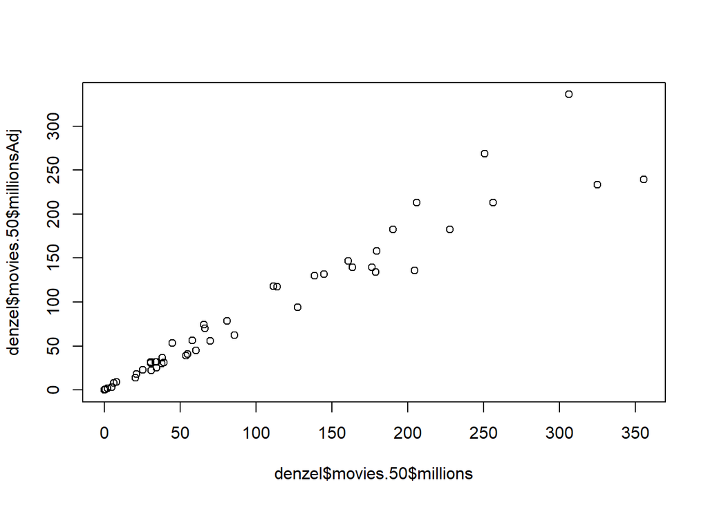

```r
plot(denzel$movies.50$millions,denzel$movies.50$millionsAdj);
```

```r
## you should repeat for will (Will Smith) ...
```

### 5.4.2 Total Votes (Divide by 1,000,000)

### 5.4.3 Average Ratings

### 5.4.4 Year? Minutes?

### 5.4.5 Metacritic (NA values)

```r
# I demo'd some standarization procedures earlier in this notebook.
#     I will leave it up to you to review that code as you finalize your analysis.

# I believe my z-score calculator will keep NA values as NA ...
#       don't omit until you are plotting ... otherwise your dataframes may be
#       unequal in length.
```